# The Discrimination Parameter and Different Deadlines: A Look at the Table Game

Abe Hofman

18 May 2016

```r
rm(list = ls())
# load('2016 Alpha Estimation/dataTableGame.Rdata')
load('dataTableGame.Rdata')

library(plyr)

all$deadline <-  as.factor(all$maximum_response_in_seconds)
```

## Introduction

Is there an effect of the deadline on the item discrimination parameter and/or on the item difficulty?

As described by Maris & van der Maas (2012), in the psychometric model based on SRT scoring rule it is expected that the deadline functions as the discrimination parameter in the 2-pl model:

$P(X=1 | \theta) = \frac{exp( d \theta)}{1 + exp( d \theta)}$

Systematic variation of the deadline, for the same item, provides a powerful test for this model. To investigate this I analysed data from the table game. In this game items of the tables 1 to 10 are presented with 4 different deadlines: 5, 10, 15 or 20 seconds. Based on the SRT scoring rule, it is expected that the discrimination parameter increases when the deadline increases.

## Methods

To estimate the discrimination parameter seperate logistic regression models were estimated, one for each item and each deadline (N=400). The observed answer (cor vs incor) was predicted by the estimated theta and beta’s based on the ELO and SRT model. Altough this method is not optimal, simulations showed that the discrimination parameter could be recoverd to an acceptable extend using this approach.

In a second step, I use linear regression models were both the beta’s and the alpha are predicted by the deadline and the table to which the item belongs.

#### Some details:

- Responses are only selected when the player has made at least 30 items, such that theta estimate is reliable
- Responses are only selected when the item has been made at least 1000 times, such that theta estimate is reliable

## Results

### Effect on Alpha’s

As predicted based on the SRT model, items with a longer deadline have an higher alpha than items with shorter a deadline.

```r
mod <- lm(alpha ~ deadline, data = all)
summary(mod)
```

```
##
## Call:
## lm(formula = alpha ~ deadline, data = all)
##
## Residuals:
##      Min       1Q   Median       3Q      Max
## -0.30256 -0.09092  0.00959  0.08549  0.35125
##
## Coefficients:
##             Estimate Std. Error t value Pr(>|t|)
## (Intercept)  0.60607    0.01191   50.89   <2e-16 ***
## deadline10   0.17013    0.01684   10.10   <2e-16 ***
## deadline15   0.23126    0.01684   13.73   <2e-16 ***
## deadline20   0.23531    0.01684   13.97   <2e-16 ***
## ---
## Signif. codes:  0 '***' 0.001 '**' 0.01 '*' 0.05 '.' 0.1 ' ' 1
##
## Residual standard error: 0.1191 on 396 degrees of freedom
## Multiple R-squared:  0.3935, Adjusted R-squared:  0.3889
## F-statistic: 85.66 on 3 and 396 DF,  p-value: < 2.2e-16
```

### Effect on Beta’s

Items with longer deadline are easier than items with shorter deadline.

```r
mod <- lm(rating ~ deadline, data = all)
summary(mod)
```

```
##
## Call:
## lm(formula = rating ~ deadline, data = all)
##
## Residuals:
##    Min     1Q Median     3Q    Max
## -4.328 -1.299 -0.410  1.527  4.988
##
## Coefficients:
##             Estimate Std. Error t value Pr(>|t|)
## (Intercept)   2.5807     0.1966   13.12   <2e-16 ***
## deadline10   -3.1062     0.2781  -11.17   <2e-16 ***
## deadline15   -3.5273     0.2781  -12.69   <2e-16 ***
## deadline20   -3.6318     0.2781  -13.06   <2e-16 ***
## ---
## Signif. codes:  0 '***' 0.001 '**' 0.01 '*' 0.05 '.' 0.1 ' ' 1
##
## Residual standard error: 1.966 on 396 degrees of freedom
## Multiple R-squared:  0.3686, Adjusted R-squared:  0.3638
## F-statistic: 77.05 on 3 and 396 DF,  p-value: < 2.2e-16
```

### Plots

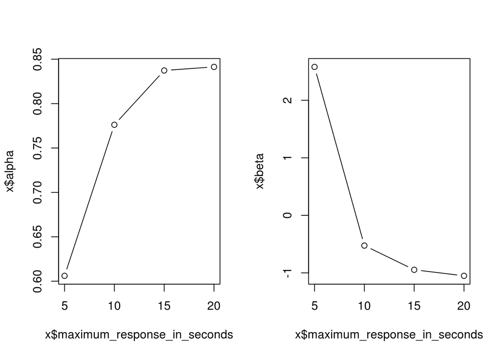

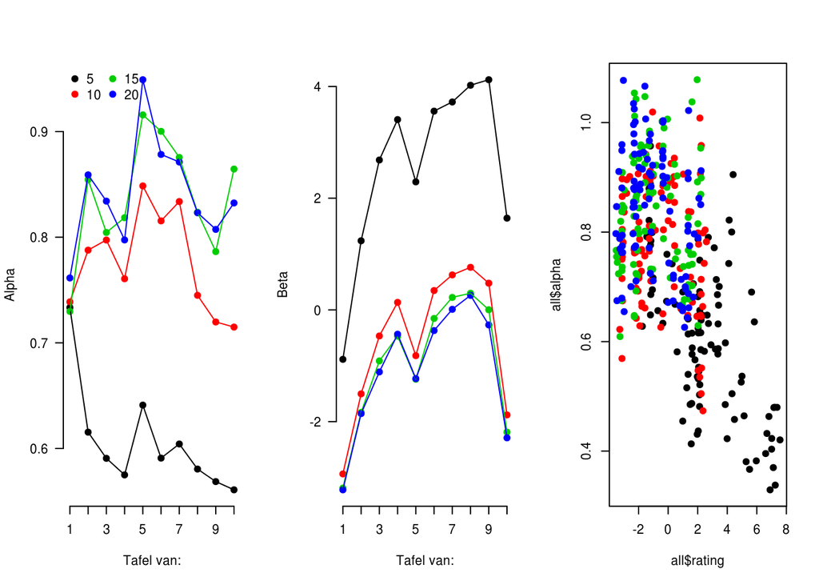

## Conclusion

Longer deadlines result in higher discrimination parameters for the table game.

But also an effect is found the item difficulty. Is this related to the adaptive data selection in the Math Garden? Are items with theoretical equal difficulties now estimated at a different beta when the discrimination is different? Item difficulty is now defined by data collected at p = .75 while, can this explain the effect of deadline on item difficulty?